# Package Management Quick Reference

Andy Lathrop

March 23, 2016

#### Built with Microsoft R Open version 3.2.3. More info at https://mran.revolutionanalytics.com/open/

#### The current CRAN repository for local packages is https://mran.revolutionanalytics.com/snapshot/2016-01-01

#### The current MRAN repository is https://mran.revolutionanalytics.com/timemachine/

Setup options: echo means R code will be displayed | cache means results will be stored for future knits

```r
knitr::opts_chunk$set(echo = TRUE, cache = TRUE)
```

# Admin notes

This is an R markdown document and requires the ‘rmarkdown’ package

```r
install.packages('rmarkdown', repos='http://cran.us.r-project.org')
library(rmarkdown)
```

# Package management utilities

The list of CRAN mirrors can be found at https://cran.r-project.org/mirrors.html

## Repo used by current R session

```r
getOption("repos")
```

```
##                                                       CRAN
## "https://mran.revolutionanalytics.com/snapshot/2016-01-01"
```

## Current local library

```r
normalizePath(.libPaths(), winslash = "/")
```

```
## [1] "C:/Program Files/Microsoft/MRO/R-3.2.3/library"
```

## Local library of packages

```r
installed.packages()[, "Package"]
```

```
##      assertthat            base       base64enc              BB
##    "assertthat"          "base"     "base64enc"            "BB"
##              BH          bitops            boot            brew
##            "BH"        "bitops"          "boot"          "brew"
##         caTools      checkpoint           class         cluster
##       "caTools"    "checkpoint"         "class"       "cluster"
##       codetools      colorspace        compiler          crayon
##     "codetools"    "colorspace"      "compiler"        "crayon"
##            curl        datasets             DBI        devtools
##          "curl"      "datasets"           "DBI"      "devtools"
##         dfoptim       dichromat          digest      doParallel
##       "dfoptim"     "dichromat"        "digest"    "doParallel"
##           dplyr           e1071        evaluate         foreach
##         "dplyr"         "e1071"      "evaluate"       "foreach"
##        forecast         foreign         formatR         Formula
##      "forecast"       "foreign"       "formatR"       "Formula"
##        fracdiff             gam             gbm       ggfortify
##      "fracdiff"           "gam"           "gbm"     "ggfortify"
##         ggplot2           git2r          glmnet        graphics
##       "ggplot2"         "git2r"        "glmnet"      "graphics"
##       grDevices            grid        gridBase       gridExtra
##     "grDevices"          "grid"      "gridBase"     "gridExtra"
##          gtable           highr          HSAUR2       htmltools
##        "gtable"         "highr"        "HSAUR2"     "htmltools"
##            httr      igraphdata           irlba            ISLR
##          "httr"    "igraphdata"         "irlba"          "ISLR"
##       iterators        jsonlite      KernSmooth           knitr
##     "iterators"      "jsonlite"    "KernSmooth"         "knitr"
##        labeling         lattice    latticeExtra        lazyeval
##      "labeling"       "lattice"  "latticeExtra"      "lazyeval"
##           leaps        magrittr        markdown            MASS
##         "leaps"      "magrittr"      "markdown"          "MASS"
##          Matrix    MatrixModels         memoise         methods
##        "Matrix"  "MatrixModels"       "memoise"       "methods"
##            mgcv            mime         munsell            nlme
##          "mgcv"          "mime"       "munsell"          "nlme"
##             NLP            nnet        numDeriv         openssl
##           "NLP"          "nnet"      "numDeriv"       "openssl"
##       optextras         packrat          pacman        parallel
##     "optextras"       "packrat"        "pacman"      "parallel"
```

[output cut: 13 more lines]

```
##    "rstudioapi"     "rversions"        "Rvmmin"      "sandwich"
##          scales          setRNG         spatial         splines
##        "scales"        "setRNG"       "spatial"       "splines"
##           stats          stats4         stringi         stringr
##         "stats"        "stats4"       "stringi"       "stringr"
##        survival          svUnit           tcltk         TH.data
##      "survival"        "svUnit"         "tcltk"       "TH.data"
##           tidyr        timeDate           tools    translations
##         "tidyr"      "timeDate"         "tools"  "translations"
##            tree         tseries             TTR           utils
##          "tree"       "tseries"           "TTR"         "utils"
##         whisker           withr            xml2          xtable
##       "whisker"         "withr"          "xml2"        "xtable"
##             xts            yaml             zoo
##           "xts"          "yaml"           "zoo"
```

## Choose CRAN mirror site from list

#### (remove # to run code)

```r
# chooseCRANmirror()
```

## Choose a CRAN repo via URL

```r
options(repos=structure(c(CRAN="http://cran.us.r-project.org")))
```

## Install from a particular mirror

```r
install.packages('rmarkdown', repos='http://cran.us.r-project.org')
```

## Permanently set CRAN repo

#### (does not work with Microsoft R distro)

```r
local({
  r <- getOption("repos")
  r["CRAN"] <- "http://cran.us.r-project.org"
  options(repos = r)
})
```

## Add CRAN repos

#### (remove # to run code)

```r
# setRepositories(addURLs =
#                   c(CRANxtras = "http://cran.us.r-project.org"))
# setRepositories(addURLs =
#                   c(CRAN = "http://cran.us.r-project.org"))
```

## Packages w/ newer versions available

```r
old.packages()
```

# About using Microsoft R distribution

#### Microsoft uses the MRAN repo for packages, usually a snapshot of the Austria CRAN repo from the first of the month

**(more info at https://mran.revolutionanalytics.com/timemachine/ )**

The ‘checkpoint’ package from MSFT is helpful for using a specific repo snapshot more info at http://bit.ly/1Rzrqdy

- When you create a checkpoint, the checkpoint() function performs the following:
  - Creates a snapshot folder to install packages. This library folder is located at ~/.checkpoint
  - Scans your project folder for all packages used. Specifically, it searches for all instances of library() and requires() in your code.
  - Installs these packages from the MRAN snapshot into your snapshot folder using install.packages()
  - Sets options for your CRAN mirror to point to a MRAN snapshot, i.e. modify options(repos)

This means the remainder of your script will run with the packages from a specific date.

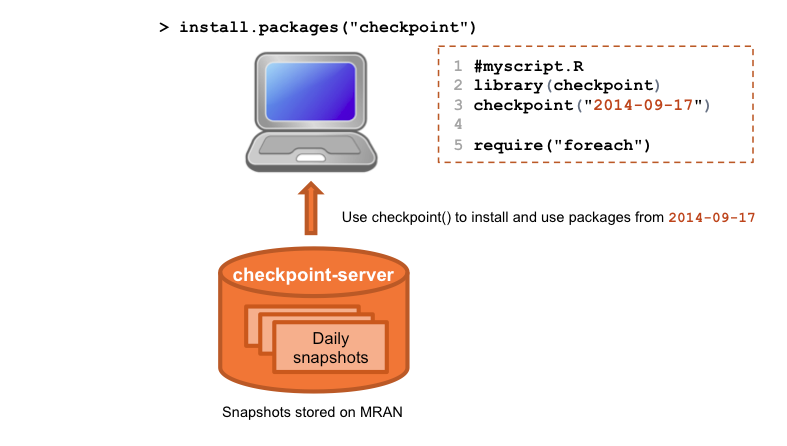